# RPE

Jae Min Jung

2023-06-09: updated on 2023-11-17

# 1 Library package

- Short cut for code chunk: ctrl + alt + i
- To execute command: ctl + enter
- pipe operator: ctl + shift + M

```r
require(tidyverse)
require(haven)
require(labelled)
require(sjlabelled)
```

```r
require(sjPlot)
require(janitor)
require(naniar)
```

# 2 Data setup

```r
df <- read_sav("Research+Participation+Experience+Survey-Fall+2021_June+8,+2023_19.26.sav")
view(df)

dim(df)
```

```
## [1] 113 129
```

```r
head(df)
```

```
## # A tibble: 6 × 129
##   StartDate           EndDate             Status         IPAddress      Progress
##   <dttm>              <dttm>              <dbl+lbl>      <chr>             <dbl>
## 1 2021-11-24 10:43:49 2021-11-24 10:45:54 0 [IP Address] 47.145.155.74       100
## 2 2021-11-24 10:46:28 2021-11-24 10:46:39 0 [IP Address] 47.145.155.74       100
## 3 2021-11-24 10:46:56 2021-11-24 10:47:05 0 [IP Address] 47.145.155.74       100
## 4 2021-11-24 10:39:59 2021-11-24 10:47:07 0 [IP Address] 72.219.128.214      100
## 5 2021-11-24 10:43:12 2021-11-24 10:52:21 0 [IP Address] 70.93.190.48        100
## 6 2021-11-24 10:47:23 2021-11-24 10:54:27 0 [IP Address] 47.145.155.74       100
## # ℹ 124 more variables: Duration__in_seconds_ <dbl>, Finished <dbl+lbl>,
## #   RecordedDate <dttm>, ResponseId <chr>, RecipientLastName <chr>,
## #   RecipientFirstName <chr>, RecipientEmail <chr>, ExternalReference <chr>,
## #   LocationLatitude <chr>, LocationLongitude <chr>, DistributionChannel <chr>,
## #   UserLanguage <chr>, Q1.1 <dbl+lbl>, Q2.2_1 <dbl+lbl>, Q2.2_2 <dbl+lbl>,
## #   Q2.2_3 <dbl+lbl>, Q2.2_5 <dbl+lbl>, Q2.2_6 <dbl+lbl>, Q2.2_4 <dbl+lbl>,
## #   Q2.2_4_TEXT <chr>, Q2.3 <dbl+lbl>, Q2.4_1 <dbl+lbl>, Q2.4_2 <dbl+lbl>, …
```

```r
glimpse(df)
```

```
## Rows: 113
## Columns: 129
## $ StartDate             <dttm> 2021-11-24 10:43:49, 2021-11-24 10:46:28, 2021-…
## $ EndDate               <dttm> 2021-11-24 10:45:54, 2021-11-24 10:46:39, 2021-…
## $ Status                <dbl+lbl> 0, 0, 0, 0, 0, 0, 0, 0, 0, 0, 0, 0, 0, 0, 0,…
## $ IPAddress             <chr> "47.145.155.74", "47.145.155.74", "47.145.155.74…
## $ Progress              <dbl> 100, 100, 100, 100, 100, 100, 100, 100, 100, 100…
## $ Duration__in_seconds_ <dbl> 125, 11, 9, 428, 548, 424, 610, 426, 608, 791, 2…
## $ Finished              <dbl+lbl> 1, 1, 1, 1, 1, 1, 1, 1, 1, 1, 1, 1, 1, 1, 1,…
## $ RecordedDate          <dttm> 2021-11-24 10:45:55, 2021-11-24 10:46:40, 2021-…
## $ ResponseId            <chr> "R_3FX1vtU0qwzUJwl", "R_33e9FCyGOaA8cGv", "R_1K9…
## $ RecipientLastName     <chr> "", "", "", "", "", "", "", "", "", "", "", "", …
## $ RecipientFirstName    <chr> "", "", "", "", "", "", "", "", "", "", "", "", …
## $ RecipientEmail        <chr> "", "", "", "", "", "", "", "", "", "", "", "", …
## $ ExternalReference     <chr> "", "", "", "", "", "", "", "", "", "", "", "", …
```

[output cut: 116 more lines]

# 3 Data cleaning

```r
df <- df |> clean_names()

names(df)
```

```
##   [1] "start_date"           "end_date"             "status"
##   [4] "ip_address"           "progress"             "duration_in_seconds"
##   [7] "finished"             "recorded_date"        "response_id"
##  [10] "recipient_last_name"  "recipient_first_name" "recipient_email"
##  [13] "external_reference"   "location_latitude"    "location_longitude"
##  [16] "distribution_channel" "user_language"        "q1_1"
##  [19] "q2_2_1"               "q2_2_2"               "q2_2_3"
##  [22] "q2_2_5"               "q2_2_6"               "q2_2_4"
##  [25] "q2_2_4_text"          "q2_3"                 "q2_4_1"
##  [28] "q2_4_2"               "q2_4_3"               "q2_4_4"
##  [31] "q2_4_4_text"          "q2_5"                 "q2_6"
##  [34] "q2_6_14_text"         "q2_7"                 "q2_8"
##  [37] "q2_9"                 "q2_10_1"              "q2_10_2"
##  [40] "q2_10_3"              "q2_10_4"              "q2_10_5"
##  [43] "q2_10_6"              "q2_10_6_text"         "q2_11"
```

[output cut: 28 more lines]

```r
head(df)
```

```
## # A tibble: 6 × 129
##   start_date          end_date            status         ip_address     progress
##   <dttm>              <dttm>              <dbl+lbl>      <chr>             <dbl>
## 1 2021-11-24 10:43:49 2021-11-24 10:45:54 0 [IP Address] 47.145.155.74       100
## 2 2021-11-24 10:46:28 2021-11-24 10:46:39 0 [IP Address] 47.145.155.74       100
## 3 2021-11-24 10:46:56 2021-11-24 10:47:05 0 [IP Address] 47.145.155.74       100
## 4 2021-11-24 10:39:59 2021-11-24 10:47:07 0 [IP Address] 72.219.128.214      100
## 5 2021-11-24 10:43:12 2021-11-24 10:52:21 0 [IP Address] 70.93.190.48        100
## 6 2021-11-24 10:47:23 2021-11-24 10:54:27 0 [IP Address] 47.145.155.74       100
## # ℹ 124 more variables: duration_in_seconds <dbl>, finished <dbl+lbl>,
## #   recorded_date <dttm>, response_id <chr>, recipient_last_name <chr>,
## #   recipient_first_name <chr>, recipient_email <chr>,
## #   external_reference <chr>, location_latitude <chr>,
## #   location_longitude <chr>, distribution_channel <chr>, user_language <chr>,
## #   q1_1 <dbl+lbl>, q2_2_1 <dbl+lbl>, q2_2_2 <dbl+lbl>, q2_2_3 <dbl+lbl>,
## #   q2_2_5 <dbl+lbl>, q2_2_6 <dbl+lbl>, q2_2_4 <dbl+lbl>, q2_2_4_text <chr>, …
```

```r
view_df(df)
```

```
## Following 27 variables have only missing values and are not shown:
```

```
## q2_2_3 [21], q2_2_4 [24], q2_4_3 [29], q2_4_4 [30], q2_10_3 [40], q2_10_6 [43], q4_2_2 [68], q8_2 [91], q8_3 [92], q8_4 [93], q8_5 [94], q8_6 [95], q9_2 [96], q9_3 [97], q9_4 [98], q9_5 [99], q9_6 [100], q9_7 [101], q9_8 [102], q9_9 [103], q10_2 [104], q10_3 [105], q10_4 [106], q10_5 [107], q10_6…
```

Data frame: df

[output not shown]

[output cut: 72 more lines]

```r
df <- df |>
  #select(q2_3) |>
  rename(att_check = q2_3)

df |>
  count(att_check)
```

```
## # A tibble: 5 × 2
##   att_check      n
##   <dbl+lbl>  <int>
## 1  2 [White]    13
## 2  3 [Red]       2
## 3  4 [Green]    93
## 4  5 [Grey]      4
## 5 NA             1
```

```r
df |>
  count(att_check) |>
  mutate(percent = n/sum(n)) # how to round it up?
```

```
## # A tibble: 5 × 3
##   att_check      n percent
##   <dbl+lbl>  <int>   <dbl>
## 1  2 [White]    13 0.115
## 2  3 [Red]       2 0.0177
## 3  4 [Green]    93 0.823
## 4  5 [Grey]      4 0.0354
## 5 NA             1 0.00885
```

```r
df <- df |>
  filter(att_check == 4)

df
```

```
## # A tibble: 93 × 129
##    start_date          end_date            status         ip_address    progress
##    <dttm>              <dttm>              <dbl+lbl>      <chr>            <dbl>
##  1 2021-11-24 10:39:59 2021-11-24 10:47:07 0 [IP Address] 72.219.128.2…      100
##  2 2021-11-24 10:43:12 2021-11-24 10:52:21 0 [IP Address] 70.93.190.48       100
##  3 2021-11-24 10:47:23 2021-11-24 10:54:27 0 [IP Address] 47.145.155.74      100
##  4 2021-11-24 10:45:48 2021-11-24 10:55:59 0 [IP Address] 172.56.17.35       100
##  5 2021-11-24 10:51:34 2021-11-24 10:58:40 0 [IP Address] 172.58.31.185      100
##  6 2021-11-24 10:48:35 2021-11-24 10:58:44 0 [IP Address] 142.129.235.…      100
##  7 2021-11-24 10:51:20 2021-11-24 11:04:32 0 [IP Address] 12.34.188.234      100
##  8 2021-11-24 11:04:11 2021-11-24 11:08:36 0 [IP Address] 76.169.192.2…      100
##  9 2021-11-24 11:08:38 2021-11-24 11:15:44 0 [IP Address] 47.229.106.27      100
## 10 2021-11-24 11:11:05 2021-11-24 11:18:17 0 [IP Address] 47.34.147.9        100
## # ℹ 83 more rows
## # ℹ 124 more variables: duration_in_seconds <dbl>, finished <dbl+lbl>,
## #   recorded_date <dttm>, response_id <chr>, recipient_last_name <chr>,
## #   recipient_first_name <chr>, recipient_email <chr>,
## #   external_reference <chr>, location_latitude <chr>,
## #   location_longitude <chr>, distribution_channel <chr>, user_language <chr>,
## #   q1_1 <dbl+lbl>, q2_2_1 <dbl+lbl>, q2_2_2 <dbl+lbl>, q2_2_3 <dbl+lbl>, …
```

```r
df |> count(q1_1)
```

```
## # A tibble: 1 × 2
##   q1_1                                                       n
##   <dbl+lbl>                                              <int>
## 1 1 [Yes, I would like to participate in this research.]    93
```

```r
df |> count(q2_2_1)
```

```
## # A tibble: 2 × 2
##   q2_2_1                               n
##   <dbl+lbl>                        <int>
## 1  1 [BUS3102-01, Dr. Ong, Online]     3
## 2 NA                                  90
```

```r
df |> count(q2_2_2)
```

```
## # A tibble: 2 × 2
##   q2_2_2                                     n
##   <dbl+lbl>                              <int>
## 1  1 [IBM3001-02, Dr. Ong, MW 4:00-5:15]     4
## 2 NA                                        89
```

```r
df |> count(q2_2_5)
```

```
## # A tibble: 2 × 2
##   q2_2_5                                  n
##   <dbl+lbl>                           <int>
## 1  1 [IBM3012-04, Dr. Jung, Online\n]    87
## 2 NA                                      6
```

```r
df |> count(q2_2_6)
```

```
## # A tibble: 2 × 2
##   q2_2_6                                                n
##   <dbl+lbl>                                         <int>
## 1  1 [IBM3012-06, Dr. Hossain, We, 7:00PM - 8:15PM]     1
## 2 NA                                                   92
```

```r
df %>% count(q2_2_3)
```

```
## # A tibble: 1 × 2
##   q2_2_3        n
##   <dbl+lbl> <int>
## 1 NA           93
```

```r
# renaming variables

df <- df |>
  rename(class_ong_online = q2_2_1,
         class_ong_mw = q2_2_2,
         class_jung_online = q2_2_5,
         class_hossain = q2_2_6,
         incent_required = q2_4_1,
         incent_extra = q2_4_2,
         college = q2_5,
         major = q2_6,
         studies = q2_7,
         mr_chapter = q2_8,
         rel_val = q2_9,
         like_mr_ch_ot_ch = q2_11,
         like_rp_mr_ch = q2_12,
         help_unst_mr_ch = q2_13,
         help_gain_know_g_mr = q2_14,
         help_unst_mktg_gen = q2_15,
         at_rp_bad_good = q5_2,
         at_rp_neg_pos = q5_3,
         at_rp_boring_fun = q5_4,
         at_rp_useless_ful = q5_5,
         val_not_worth_time = q5_6,
         val_not_worth_eff = q5_7,
         val_bus_majors = q5_8,
         val_non_bus_majors = q5_9,
         rp_limited_to_mkt = q5_10,
         part_intention_5_sd = q5_11,
         credit_earned = q3_2,
         study_type = q3_3,
         rp_motive = q3_4,
         studies_sincerity = q3_5,
         studies_interest = q3_6,
         studies_qual_b_g = q3_7,
         studies_qual_lo_hi = q3_8,
         help_unst_mr_better = q4_3,
         help_unst_mkt_con = q4_4,
         learned_mkt = q4_5,
         enhanced_know_mkt = q4_6,
         sat_brp_enrol = q6_2,
         sat_brp_navi = q6_3,
         sat_brp_auto_email = q6_4,
         att_brp_ifc = q6_5,
         sat_brp_qna_sona = q6_6,
         sat_app_time_conv = q6_7,
         s_tech_rt_24 = q7_2,
         s_tech_rt_rea = q7_3,
         s_tech_helpful = q7_4,
         s_tech_courteous = q7_5,
         s_tech_resp_sat = q7_6,
         s_tech_resp_rea = q7_7,
         s_tech_overal_sat = q7_8,
         ov_rp_good_exp = q11_2,
         ov_rp_pos_ex = q11_3,
         ov_rp_gr_valu = q11_4,
         int_rp_recomend = q11_5,
         int_rp_likely = q11_6,
         gender = q12_2,
         age = q12_3,
         cntry_born = q12_4,
         cntry_gru_14 = q12_5,
         yrs_lvd_us = q12_6,
         race_eth = q12_7,
         culture = q12_8,
         hrs_work_wk = q12_9,
         days_camp_wk = q12_10,
         gpa_cpp = q12_11)

names(df)
```

```
##   [1] "start_date"           "end_date"             "status"
##   [4] "ip_address"           "progress"             "duration_in_seconds"
##   [7] "finished"             "recorded_date"        "response_id"
##  [10] "recipient_last_name"  "recipient_first_name" "recipient_email"
##  [13] "external_reference"   "location_latitude"    "location_longitude"
##  [16] "distribution_channel" "user_language"        "q1_1"
##  [19] "class_ong_online"     "class_ong_mw"         "q2_2_3"
##  [22] "class_jung_online"    "class_hossain"        "q2_2_4"
##  [25] "q2_2_4_text"          "att_check"            "incent_required"
##  [28] "incent_extra"         "q2_4_3"               "q2_4_4"
##  [31] "q2_4_4_text"          "college"              "major"
##  [34] "q2_6_14_text"         "studies"              "mr_chapter"
##  [37] "rel_val"              "q2_10_1"              "q2_10_2"
##  [40] "q2_10_3"              "q2_10_4"              "q2_10_5"
##  [43] "q2_10_6"              "q2_10_6_text"         "like_mr_ch_ot_ch"
```

[output cut: 28 more lines]

```r
# Expected Grade in courses from which they are

df %>% select(contains("q2_10"))
```

```
## # A tibble: 93 × 7
##    q2_10_1   q2_10_2   q2_10_3   q2_10_4            q2_10_5 q2_10_6 q2_10_6_text
##    <dbl+lbl> <dbl+lbl> <dbl+lbl> <dbl+lbl>          <dbl+l> <dbl+l> <chr>
##  1 NA        NA        NA         1 [90% and above… NA      NA      ""
##  2 NA        NA        NA         1 [90% and above… NA      NA      ""
##  3 NA        NA        NA         2 [80% and above… NA      NA      ""
##  4 NA        NA        NA         3 [70% and above… NA      NA      ""
##  5 NA        NA        NA        NA                 NA      NA      ""
##  6 NA        NA        NA         2 [80% and above… NA      NA      ""
##  7 NA        NA        NA         1 [90% and above… NA      NA      ""
##  8 NA        NA        NA         1 [90% and above… NA      NA      ""
##  9 NA        NA        NA         1 [90% and above… NA      NA      ""
## 10 NA        NA        NA         2 [80% and above… NA      NA      ""
## # ℹ 83 more rows
```

```r
df %>%
  select(contains("q2_10")) %>%
  filter(!is.na(q2_10_1))
```

```
## # A tibble: 3 × 7
##   q2_10_1               q2_10_2   q2_10_3   q2_10_4 q2_10_5 q2_10_6 q2_10_6_text
##   <dbl+lbl>             <dbl+lbl> <dbl+lbl> <dbl+l> <dbl+l> <dbl+l> <chr>
## 1 1 [90% and above (A)] NA        NA        NA      NA      NA      ""
## 2 3 [70% and above (C)] NA        NA        NA      NA      NA      ""
## 3 1 [90% and above (A)] NA        NA        NA      NA      NA      ""
```

```r
df %>%
  select(contains("q2_10")) %>%
  filter(!is.na(q2_10_2))
```

```
## # A tibble: 4 × 7
##   q2_10_1   q2_10_2               q2_10_3  q2_10_4  q2_10_5 q2_10_6 q2_10_6_text
##   <dbl+lbl> <dbl+lbl>             <dbl+lb> <dbl+lb> <dbl+l> <dbl+l> <chr>
## 1 NA        3 [70% and above (C)] NA       NA       NA      NA      ""
## 2 NA        3 [70% and above (C)] NA       NA       NA      NA      ""
## 3 NA        2 [80% and above (B)] NA        3 [70%… NA      NA      ""
## 4 NA        2 [80% and above (B)] NA        3 [70%… NA      NA      ""
```

```r
df %>%
  select(contains("q2_10")) %>%
  filter(!is.na(q2_10_3))
```

```
## # A tibble: 0 × 7
## # ℹ 7 variables: q2_10_1 <dbl+lbl>, q2_10_2 <dbl+lbl>, q2_10_3 <dbl+lbl>,
## #   q2_10_4 <dbl+lbl>, q2_10_5 <dbl+lbl>, q2_10_6 <dbl+lbl>, q2_10_6_text <chr>
```

```r
df %>%
  select(contains("q2_10")) %>%
  filter(!is.na(q2_10_4))
```

```
## # A tibble: 83 × 7
##    q2_10_1   q2_10_2   q2_10_3   q2_10_4            q2_10_5 q2_10_6 q2_10_6_text
##    <dbl+lbl> <dbl+lbl> <dbl+lbl> <dbl+lbl>          <dbl+l> <dbl+l> <chr>
##  1 NA        NA        NA        1 [90% and above … NA      NA      ""
##  2 NA        NA        NA        1 [90% and above … NA      NA      ""
##  3 NA        NA        NA        2 [80% and above … NA      NA      ""
##  4 NA        NA        NA        3 [70% and above … NA      NA      ""
##  5 NA        NA        NA        2 [80% and above … NA      NA      ""
##  6 NA        NA        NA        1 [90% and above … NA      NA      ""
##  7 NA        NA        NA        1 [90% and above … NA      NA      ""
##  8 NA        NA        NA        1 [90% and above … NA      NA      ""
##  9 NA        NA        NA        2 [80% and above … NA      NA      ""
## 10 NA        NA        NA        2 [80% and above … NA      NA      ""
## # ℹ 73 more rows
```

```r
df %>%
  select(contains("q2_10")) %>%
  filter(!is.na(q2_10_5))
```

```
## # A tibble: 1 × 7
##   q2_10_1   q2_10_2   q2_10_3   q2_10_4   q2_10_5           q2_10_6 q2_10_6_text
##   <dbl+lbl> <dbl+lbl> <dbl+lbl> <dbl+lbl> <dbl+lbl>         <dbl+l> <chr>
## 1 NA        NA        NA        NA        1 [90% and above… NA      ""
```

```r
df %>%
  select(contains("q2_10")) %>%
  filter(!is.na(q2_10_6))
```

```
## # A tibble: 0 × 7
## # ℹ 7 variables: q2_10_1 <dbl+lbl>, q2_10_2 <dbl+lbl>, q2_10_3 <dbl+lbl>,
## #   q2_10_4 <dbl+lbl>, q2_10_5 <dbl+lbl>, q2_10_6 <dbl+lbl>, q2_10_6_text <chr>
```

```r
df %>%
  select(contains("q2_10")) %>%
  filter(!is.na(q2_10_6_text))
```

```
## # A tibble: 93 × 7
##    q2_10_1   q2_10_2   q2_10_3   q2_10_4            q2_10_5 q2_10_6 q2_10_6_text
##    <dbl+lbl> <dbl+lbl> <dbl+lbl> <dbl+lbl>          <dbl+l> <dbl+l> <chr>
##  1 NA        NA        NA         1 [90% and above… NA      NA      ""
##  2 NA        NA        NA         1 [90% and above… NA      NA      ""
##  3 NA        NA        NA         2 [80% and above… NA      NA      ""
##  4 NA        NA        NA         3 [70% and above… NA      NA      ""
##  5 NA        NA        NA        NA                 NA      NA      ""
##  6 NA        NA        NA         2 [80% and above… NA      NA      ""
##  7 NA        NA        NA         1 [90% and above… NA      NA      ""
##  8 NA        NA        NA         1 [90% and above… NA      NA      ""
##  9 NA        NA        NA         1 [90% and above… NA      NA      ""
## 10 NA        NA        NA         2 [80% and above… NA      NA      ""
## # ℹ 83 more rows
```

```r
df <- df |>
  mutate(exp_grade_course = case_when(q2_10_1 %in% c(1, 2, 3, 4, 5) ~ q2_10_1,
                                      q2_10_2 %in% c(1, 2, 3, 4, 5) ~ q2_10_2,
                                      q2_10_3 %in% c(1, 2, 3, 4, 5) ~ q2_10_3,
                                      q2_10_4 %in% c(1, 2, 3, 4, 5) ~ q2_10_4,
                                      q2_10_5 %in% c(1, 2, 3, 4, 5) ~ q2_10_5))

df %>%
  count(exp_grade_course)
```

```
## # A tibble: 5 × 2
##   exp_grade_course           n
##   <dbl+lbl>              <int>
## 1  1 [90% and above (A)]    25
## 2  2 [80% and above (B)]    48
## 3  3 [70% and above (C)]    15
## 4  4 [60% and above (D)]     1
## 5 NA                         4
```

```r
df |>
  count(incent_required)
```

```
## # A tibble: 2 × 2
##   incent_required                 n
##   <dbl+lbl>                   <int>
## 1  1 [Required course credit]    61
## 2 NA                             32
```

```r
df |>
  count(incent_extra)
```

```
## # A tibble: 2 × 2
##   incent_extra          n
##   <dbl+lbl>         <int>
## 1  1 [Extra credit]    67
## 2 NA                   26
```

```r
df |>
  select(incent_required, incent_extra) %>% view()

# cross-tabulation
df |>
  group_by(incent_required) |>
  count(incent_extra)
```

```
## # A tibble: 3 × 3
## # Groups:   incent_required [2]
##   incent_required             incent_extra          n
##   <dbl+lbl>                   <dbl+lbl>         <int>
## 1  1 [Required course credit]  1 [Extra credit]    35
## 2  1 [Required course credit] NA                   26
## 3 NA                           1 [Extra credit]    32
```

# 4 Data cleaning #2

```r
#install.packages("kableExtra")
library(kableExtra)
df |>
  group_by(incent_required, incent_extra) |>
  tally() |>
  ungroup() |>
  mutate(percent = n/sum(n)) |>
  kbl(caption = "Required Credits by Extra Credit") |>
  kable_classic(full_width = F, html_font = "Cambria")
```

Required Credits by Extra Credit

| incent_required | incent_extra | n | percent |
| --- | --- | --- | --- |
| 1 | 1 | 35 | 0.3763441 |
| 1 | NA | 26 | 0.2795699 |
| NA | 1 | 32 | 0.3440860 |

```r
# Participation in the research(s) helped me understand how a good marketing
# research should be done. Strongly Disagree

view_df(df)
```

```
## Following 27 variables have only missing values and are not shown:
```

```
## q2_2_3 [21], q2_2_4 [24], q2_4_3 [29], q2_4_4 [30], q2_10_3 [40], q2_10_6 [43], q4_2_2 [68], q8_2 [91], q8_3 [92], q8_4 [93], q8_5 [94], q8_6 [95], q9_2 [96], q9_3 [97], q9_4 [98], q9_5 [99], q9_6 [100], q9_7 [101], q9_8 [102], q9_9 [103], q10_2 [104], q10_3 [105], q10_4 [106], q10_5 [107], q10_6…
```

Data frame: df

[output not shown]

[output cut: 73 more lines]

```r
df <- df |>
  mutate(help_unst_g_mr_condt = case_when(q4_2_1 == 1 ~ 1,
                                          q4_2_2 == 1 ~ 2,
                                          q4_2_3 == 1 ~ 3,
                                          q4_2_4 == 1 ~ 4,
                                          q4_2_5 == 1 ~ 5,
                                          q4_2_6 == 1 ~ 6,
                                          q4_2_7 == 1 ~ 7))
# confirm
df |> count(help_unst_g_mr_condt)
```

```
## # A tibble: 6 × 2
##   help_unst_g_mr_condt     n
##                  <dbl> <int>
## 1                    1     2
## 2                    3     7
## 3                    4    13
## 4                    5    25
## 5                    6    33
## 6                    7    13
```

```r
df |> summary()
```

```
##    start_date                        end_date                          status
##  Min.   :2021-11-24 10:39:59.00   Min.   :2021-11-24 10:47:07.00   Min.   :0
##  1st Qu.:2021-11-24 12:11:32.00   1st Qu.:2021-11-24 12:50:14.00   1st Qu.:0
##  Median :2021-11-25 15:53:25.00   Median :2021-11-25 16:05:26.00   Median :0
##  Mean   :2021-11-28 01:43:10.74   Mean   :2021-11-28 01:54:36.30   Mean   :0
##  3rd Qu.:2021-12-01 14:56:04.00   3rd Qu.:2021-12-01 15:04:50.00   3rd Qu.:0
##  Max.   :2021-12-06 20:42:47.00   Max.   :2021-12-06 20:51:39.00   Max.   :0
##
##   ip_address           progress   duration_in_seconds    finished
##  Length:93          Min.   :100   Min.   :  215       Min.   :1
##  Class :character   1st Qu.:100   1st Qu.:  353       1st Qu.:1
##  Mode  :character   Median :100   Median :  433       Median :1
##                     Mean   :100   Mean   :  685       Mean   :1
##                     3rd Qu.:100   3rd Qu.:  610       3rd Qu.:1
##                     Max.   :100   Max.   :11509       Max.   :1
##
##  recorded_date                    response_id        recipient_last_name
##  Min.   :2021-11-24 10:47:08.00   Length:93          Length:93
##  1st Qu.:2021-11-24 12:50:14.00   Class :character   Class :character
##  Median :2021-11-25 16:05:26.00   Mode  :character   Mode  :character
##  Mean   :2021-11-28 01:54:36.75
##  3rd Qu.:2021-12-01 15:04:51.00
##  Max.   :2021-12-06 20:51:39.00
##
##  recipient_first_name recipient_email    external_reference location_latitude
##  Length:93            Length:93          Length:93          Length:93
##  Class :character     Class :character   Class :character   Class :character
##  Mode  :character     Mode  :character   Mode  :character   Mode  :character
##
##
##
##
##  location_longitude distribution_channel user_language           q1_1
##  Length:93          Length:93            Length:93          Min.   :1
##  Class :character   Class :character     Class :character   1st Qu.:1
##  Mode  :character   Mode  :character     Mode  :character   Median :1
##                                                             Mean   :1
##                                                             3rd Qu.:1
##                                                             Max.   :1
##
```

[output cut: 193 more lines]

```
##  Min.   : 0.000   Min.   :2.000   Length:93          Min.   :1.00
##  1st Qu.: 0.000   1st Qu.:3.015   Class :character   1st Qu.:1.00
##  Median : 0.000   Median :3.300   Mode  :character   Median :2.00
##  Mean   : 1.097   Mean   :3.309                      Mean   :1.91
##  3rd Qu.: 2.000   3rd Qu.:3.500                      3rd Qu.:2.00
##  Max.   :15.000   Max.   :4.000                      Max.   :4.00
##  NA's   :3        NA's   :14                         NA's   :4
##  help_unst_g_mr_condt
##  Min.   :1.000
##  1st Qu.:5.000
##  Median :5.000
##  Mean   :5.258
##  3rd Qu.:6.000
##  Max.   :7.000
##
```

# 5 Research questions submitted by RA’s

- One student’s interest
  1. what factors contribute to employee job satisfaction to a specific organization in the dataset? (X)
  2. Is there a correlation between customers’ satisfaction levels and their likelihood of making repeat purchases? (O)
  3. Are there any relationships between the participants’ education levels and their income or job satisfaction? (~)
- “How does the students’ level of interest and sincerity in participating in research studies relate to their expected final grade, major, and the number of studies they have previously participated in?” (0)
- Would students be willing to participate in research if there were no incentives offered? (~)
- Are students willing to put more time in research if the topic is interesting to them or if it is required for credits? (~)

# 6 Investigation of Research Questions

## 6.1 RQ 1. Willinness to participate and *interest* vs. *required*? (**Jae Jung**)

5. Are students willing to put more time in research if the topic is interesting to them or if it is required for credits? (~)
- Are students more willing to participate again in research if the topic is interesting to them or if it is required for credits? (~)
  - interest (I.V.)
    - studies_interest = q3_6: “How interested were you in participating in the studies?” (a 5-point likeer type scale)
  - incentive type (I.V.)
    - incent_required, incent_extra
  - Participation intention (D.v.)
    - part_intention_sd = q5_11: “How likely is it that you participate in research studies next time you are given a chance?”
    - int_rp_likely = Q11_6: “I am likely to participate again in research studies when given a chance.”
    - int_rp_recomend = Q11_5: “I would strongly recommend research participation to other students.’

### 6.1.1 Exploratory Analysis

- *Findings:*

#### 6.1.1.1 Interest (IV)

```r
df |> count(studies_interest)
```

```
## # A tibble: 5 × 2
##   studies_interest              n
##   <dbl+lbl>                 <int>
## 1 1 [Not at all interested]     2
## 2 2 [Slightly interested]       7
## 3 3 [Somewhat interested]      23
## 4 4 [Moderately interested]    42
## 5 5 [Very much interested]     19
```

```r
df %>%
  select(studies_interest) %>%
  var_label()
```

```
## $studies_interest
## [1] "How interested were you in participating in the studies?"
```

```r
df %>%
  select(studies_interest) %>%
  labelled::val_labels()
```

```
## $studies_interest
## Not at all interested   Slightly interested   Somewhat interested
##                     1                     2                     3
## Moderately interested  Very much interested
##                     4                     5
```

#### 6.1.1.2 Incentive type (IV)

```r
df %>% count(incent_required)
```

```
## # A tibble: 2 × 2
##   incent_required                 n
##   <dbl+lbl>                   <int>
## 1  1 [Required course credit]    61
## 2 NA                             32
```

```r
df %>% count(q2_4_4_text)
```

```
## # A tibble: 1 × 2
##   q2_4_4_text     n
##   <chr>       <int>
## 1 ""             93
```

```r
df %>%
  group_by(incent_required) %>%
  count(incent_extra)
```

```
## # A tibble: 3 × 3
## # Groups:   incent_required [2]
##   incent_required             incent_extra          n
##   <dbl+lbl>                   <dbl+lbl>         <int>
## 1  1 [Required course credit]  1 [Extra credit]    35
## 2  1 [Required course credit] NA                   26
## 3 NA                           1 [Extra credit]    32
```

```r
# new variable
df <- df %>%
  mutate(incent_type = case_when(incent_required == 1 & is.na(incent_extra) ~ 1,
                                 incent_extra == 1 & is.na(incent_required) ~ 2,
                                 TRUE                                       ~ 3))
# confirm
df %>% count(incent_type)
```

```
## # A tibble: 3 × 2
##   incent_type     n
##         <dbl> <int>
## 1           1    26
## 2           2    32
## 3           3    35
```

```r
df <- df %>%
  set_value_labels(incent_type = c(required = 1,
                                   extra = 2,
                                   both = 3))

df %>% count(incent_type)
```

```
## # A tibble: 3 × 2
##   incent_type      n
##   <dbl+lbl>    <int>
## 1 1 [required]    26
## 2 2 [extra]       32
## 3 3 [both]        35
```

**Code club #11**

#### 6.1.1.3 Participation Intention

- q5_11: part_intention_5_sd
  - “How likely is it that you participate in research studies next time you are given a chance?”

# 5-point semantic differential scale

```r
df %>% count(part_intention_5_sd)
```

```
## # A tibble: 5 × 2
##   part_intention_5_sd     n
##   <dbl+lbl>           <int>
## 1 1 [1 Very unlikely]     6
## 2 2 [2]                   3
## 3 3 [3]                  21
## 4 4 [4]                  29
## 5 5 [5 Very Likely]      34
```

```r
df %>% select(part_intention_5_sd) %>%
  var_label()
```

```
## $part_intention_5_sd
## [1] "How likely is it that you participate in research studies next time you are given a chance?"
```

```r
df %>% select(part_intention_5_sd) %>%
  labelled::val_labels()
```

```
## $part_intention_5_sd
## 1 Very unlikely               2               3               4   5 Very Likely
##               1               2               3               4               5
```

- q11_6:
  - int_rp_likely: “I am likely to participate again in research studies when given a chance.”
  - 7-point Likert-type scale

```r
# participation intention
df %>%
  count(int_rp_likely)
```

```
## # A tibble: 8 × 2
##   int_rp_likely                      n
##   <dbl+lbl>                      <int>
## 1 1 [Strongly Disagree]              2
## 2 2 [Disagree]                       1
## 3 3 [Somewhat disagree]              2
## 4 4 [Neither agree nor disagree]    11
## 5 5 [Somewhat agree]                16
## 6 6 [Agree]                         27
## 7 7 [Strongly agree]                33
## 8 8                                  1
```

```r
df %>%
  select(int_rp_likely) %>%
  var_label()
```

```
## $int_rp_likely
## [1] "I am likely to participate again in research studies when given a chance."
```

```r
# clean var
df <- df %>%
  mutate(part_intention_lt = ifelse(int_rp_likely == 8, NA, int_rp_likely)) %>%
  var_labels(part_intention_lt = "I am likely to participate again in research studies when given a chance") %>%
  set_value_labels(part_intention_lt = c("Strongly Disagree" = 1,
                                         "Disagree" = 2,
                                         "Somewhat disagree" = 3,
                                         "Neither agree nor disagree" = 4,
                                         "Agree" = 5,
                                         "Somewhat agree" = 6,
                                         "Strngly Agree" = 7))

#confirm
df %>% count(part_intention_lt)
```

```
## # A tibble: 8 × 2
##   part_intention_lt                   n
##   <dbl+lbl>                       <int>
## 1  1 [Strongly Disagree]              2
## 2  2 [Disagree]                       1
## 3  3 [Somewhat disagree]              2
## 4  4 [Neither agree nor disagree]    11
## 5  5 [Agree]                         16
## 6  6 [Somewhat agree]                27
## 7  7 [Strngly Agree]                 33
## 8 NA                                  1
```

```r
var_label(df$part_intention_lt)
```

```
## [1] "I am likely to participate again in research studies when given a chance"
```

```r
labelled::val_labels(df$part_intention_lt)
```

```
##          Strongly Disagree                   Disagree
##                          1                          2
##          Somewhat disagree Neither agree nor disagree
##                          3                          4
##                      Agree             Somewhat agree
##                          5                          6
##              Strngly Agree
##                          7
```

- q11_5: int_rp_recomend
  - I would strongly recommend research participation to other students.

```r
df %>%
  count(int_rp_recomend)
```

```
## # A tibble: 7 × 2
##   int_rp_recomend                    n
##   <dbl+lbl>                      <int>
## 1 1 [Strongly Disagree]              3
## 2 2 [Disagree]                       1
## 3 3 [Somewhat disagree]              1
## 4 4 [Neither agree nor disagree]    10
## 5 5 [Somewhat agree]                16
## 6 6 [Agree]                         30
## 7 7 [Strongly agree]                32
```

##### 6.1.1.3.1 Correlation

```r
library(GGally)
```

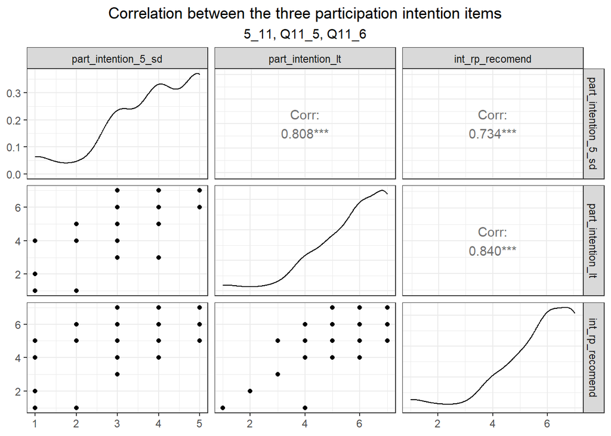

```r
df %>%
  select(part_intention_5_sd, part_intention_lt, int_rp_recomend) %>%
  ggpairs() +
  labs(title = "Correlation between the three participation intention items",
       subtitle = "5_11, Q11_5, Q11_6")+
  theme_bw()+
  theme(plot.title = element_text(hjust = 0.5),
        plot.subtitle = element_text(hjust = 0.5))
```

**Code club #12 (9/22/2023)**

#### 6.1.1.4 participation intention by interest in studies

```r
df %>% count(part_intention_lt)
```

```
## # A tibble: 8 × 2
##   part_intention_lt                   n
##   <dbl+lbl>                       <int>
## 1  1 [Strongly Disagree]              2
## 2  2 [Disagree]                       1
## 3  3 [Somewhat disagree]              2
## 4  4 [Neither agree nor disagree]    11
## 5  5 [Agree]                         16
## 6  6 [Somewhat agree]                27
## 7  7 [Strngly Agree]                 33
## 8 NA                                  1
```

```r
df %>% count(studies_interest)
```

```
## # A tibble: 5 × 2
##   studies_interest              n
##   <dbl+lbl>                 <int>
## 1 1 [Not at all interested]     2
## 2 2 [Slightly interested]       7
## 3 3 [Somewhat interested]      23
## 4 4 [Moderately interested]    42
## 5 5 [Very much interested]     19
```

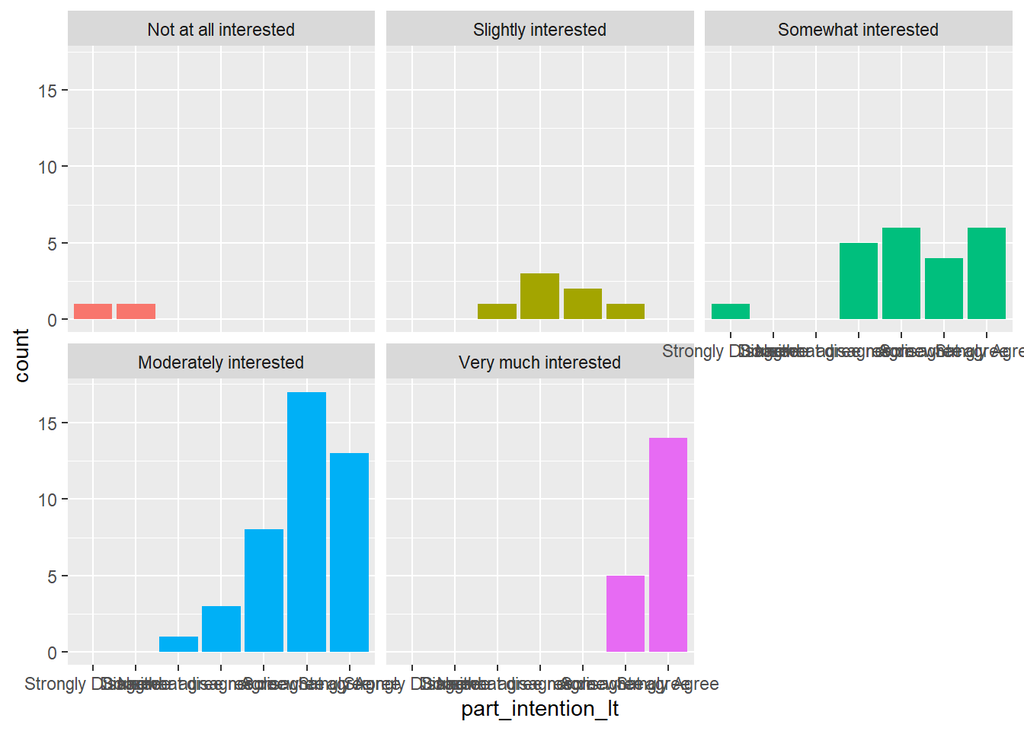

```r
# change labelled data to a factor
# faceted bar chart
df %>%
  filter(!is.na(part_intention_lt)) %>%
  mutate(part_intention_lt = haven::as_factor(part_intention_lt)) %>%
  mutate(studies_interest = haven::as_factor(studies_interest)) %>%
  ggplot(aes(part_intention_lt, fill = studies_interest)) +
  geom_bar() +
  facet_wrap(~studies_interest) +
  theme(legend.position = "none")
```

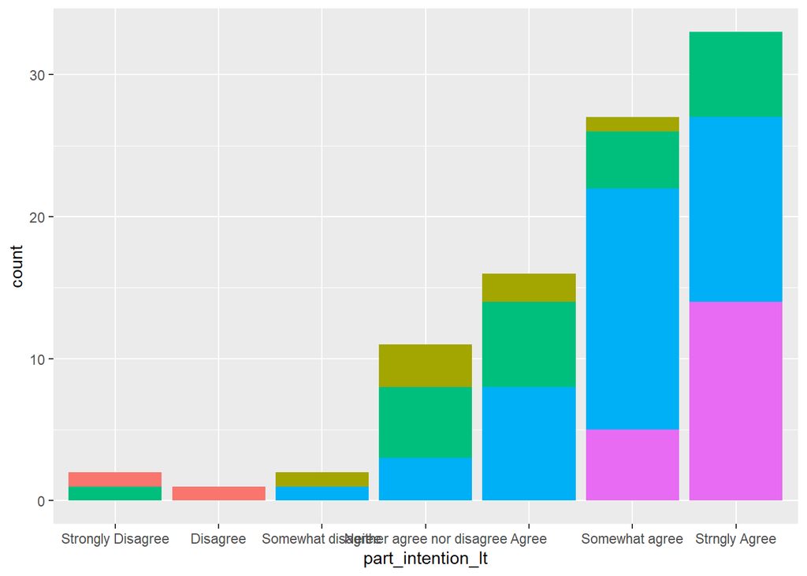

```r
# stacked bar chart: hard to interpret
df %>%
  filter(!is.na(part_intention_lt)) %>%
  mutate(part_intention_lt = haven::as_factor(part_intention_lt)) %>%
  mutate(studies_interest = haven::as_factor(studies_interest)) %>%
  ggplot(aes(part_intention_lt, fill = studies_interest)) +
  geom_bar() +
  #facet_wrap(~studies_interest) +
  theme(legend.position = "none")
```

- note only

```r
# doesn't work
df %>%
  ggplot(aes(part_intention_lt, fill = studies_interest)) +
  geom_bar() +
  facet_wrap(~studies_interest) +
  theme(legend.position = "none")
```

```r
df %>% count(part_intention_5_sd)
```

```
## # A tibble: 5 × 2
##   part_intention_5_sd     n
##   <dbl+lbl>           <int>
## 1 1 [1 Very unlikely]     6
## 2 2 [2]                   3
## 3 3 [3]                  21
## 4 4 [4]                  29
## 5 5 [5 Very Likely]      34
```

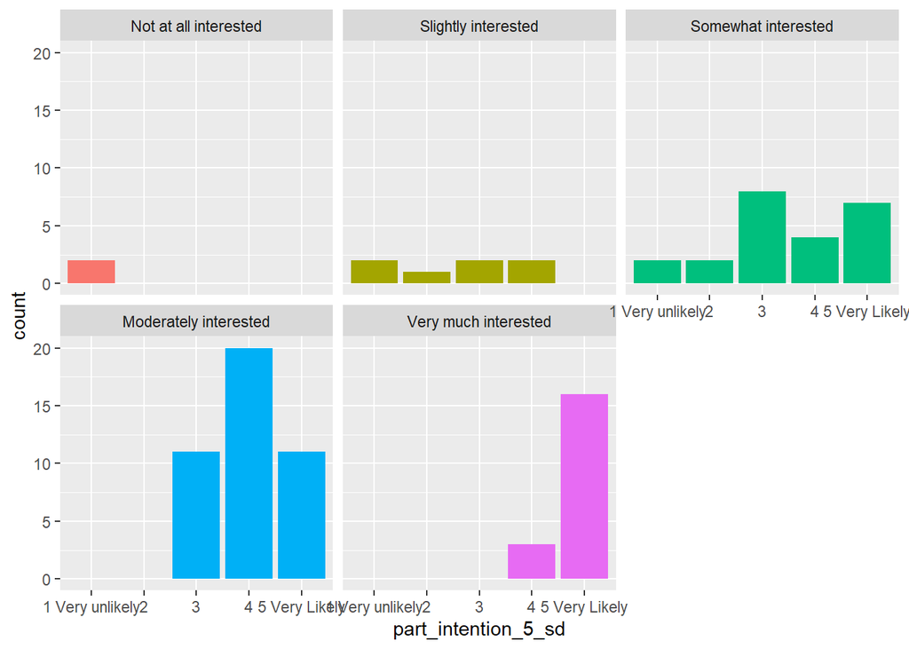

```r
df %>%
  filter(!is.na(part_intention_5_sd)) %>%
  mutate(part_intention_5_sd = haven::as_factor(part_intention_5_sd)) %>%
  mutate(studies_interest = haven::as_factor(studies_interest)) %>%
  ggplot(aes(part_intention_5_sd, fill = studies_interest)) +
  geom_bar() +
  facet_wrap(~studies_interest) +
  theme(legend.position = "none")
```

```r
df %>% count(int_rp_recomend)
```

```
## # A tibble: 7 × 2
##   int_rp_recomend                    n
##   <dbl+lbl>                      <int>
## 1 1 [Strongly Disagree]              3
## 2 2 [Disagree]                       1
## 3 3 [Somewhat disagree]              1
## 4 4 [Neither agree nor disagree]    10
## 5 5 [Somewhat agree]                16
## 6 6 [Agree]                         30
## 7 7 [Strongly agree]                32
```

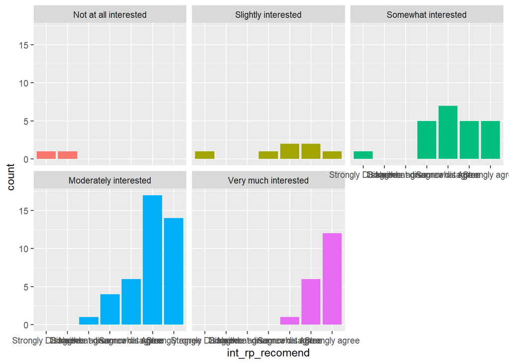

```r
df %>%
  filter(!is.na(int_rp_recomend)) %>%
  mutate(int_rp_recomend = haven::as_factor(int_rp_recomend)) %>%
  mutate(studies_interest = haven::as_factor(studies_interest)) %>%
  ggplot(aes(int_rp_recomend, fill = studies_interest)) +
  geom_bar() +
  facet_wrap(~studies_interest) +
  theme(legend.position = "none")
```

- Conclusion: Interest in studies tends to be positively associated with study participation intentions (with all three items of participation intentions).

**Code Club #13 (9/29/2023)** * We refined research questions.

**Code Club #14 (10/6/2023)**

#### 6.1.1.5 participation intentions by type of incentives.

- part_intention_lt

```r
df %>% count(part_intention_lt)
```

```
## # A tibble: 8 × 2
##   part_intention_lt                   n
##   <dbl+lbl>                       <int>
## 1  1 [Strongly Disagree]              2
## 2  2 [Disagree]                       1
## 3  3 [Somewhat disagree]              2
## 4  4 [Neither agree nor disagree]    11
## 5  5 [Agree]                         16
## 6  6 [Somewhat agree]                27
## 7  7 [Strngly Agree]                 33
## 8 NA                                  1
```

```r
df %>% count(incent_type)
```

```
## # A tibble: 3 × 2
##   incent_type      n
##   <dbl+lbl>    <int>
## 1 1 [required]    26
## 2 2 [extra]       32
## 3 3 [both]        35
```

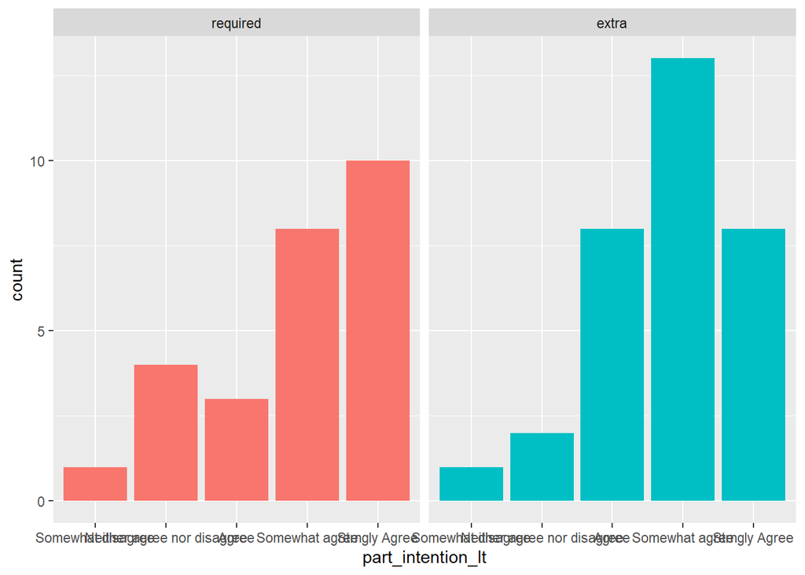

```r
# bar chart
df %>%
  filter(incent_type != 3) %>%
  filter(!is.na(part_intention_lt)) %>%
  mutate(part_intention_lt = haven::as_factor(part_intention_lt),
         incent_type = haven::as_factor(incent_type)) %>%
  ggplot(aes(part_intention_lt, fill = incent_type)) +
  geom_bar() +
  facet_wrap(~ incent_type)+
  theme(legend.position = "none")
```

```r
# means and sd's
df %>%
  select(incent_type, part_intention_lt) %>%
  filter(incent_type != 3) %>%
  filter(!is.na(part_intention_lt)) %>%
  mutate(incent_type = haven::as_factor(incent_type)) %>%
  group_by(incent_type) %>%
  summarize(count = n(),
            mean = mean(part_intention_lt),
            sd = sd(part_intention_lt))
```

```
## # A tibble: 2 × 4
##   incent_type count  mean    sd
##   <fct>       <int> <dbl> <dbl>
## 1 required       26  5.85  1.22
## 2 extra          32  5.78  1.01
```

**Code Club #16 (10/27/2023)** - spent first half of two hour session on presentation - spent the second half of the session on coding

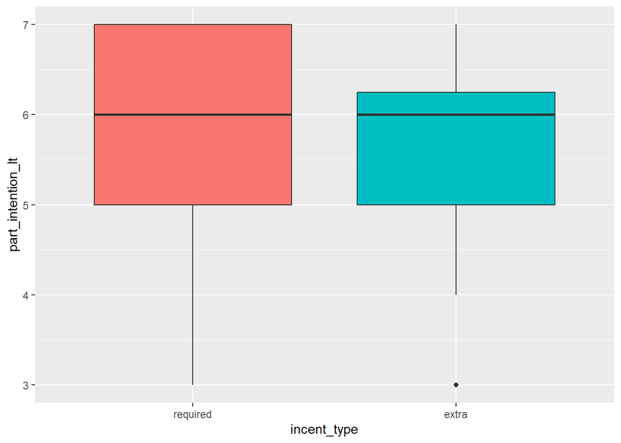

```r
#boxplot
df %>%
  select(incent_type, part_intention_lt) %>%
  filter(incent_type != 3) %>%
  filter(!is.na(part_intention_lt)) %>%
  mutate(incent_type = haven::as_factor(incent_type)) %>%
  ggplot(aes(incent_type, part_intention_lt, fill = incent_type)) +
  geom_boxplot() +
  theme(legend.position = "none")
```

- part_intention_5_sd

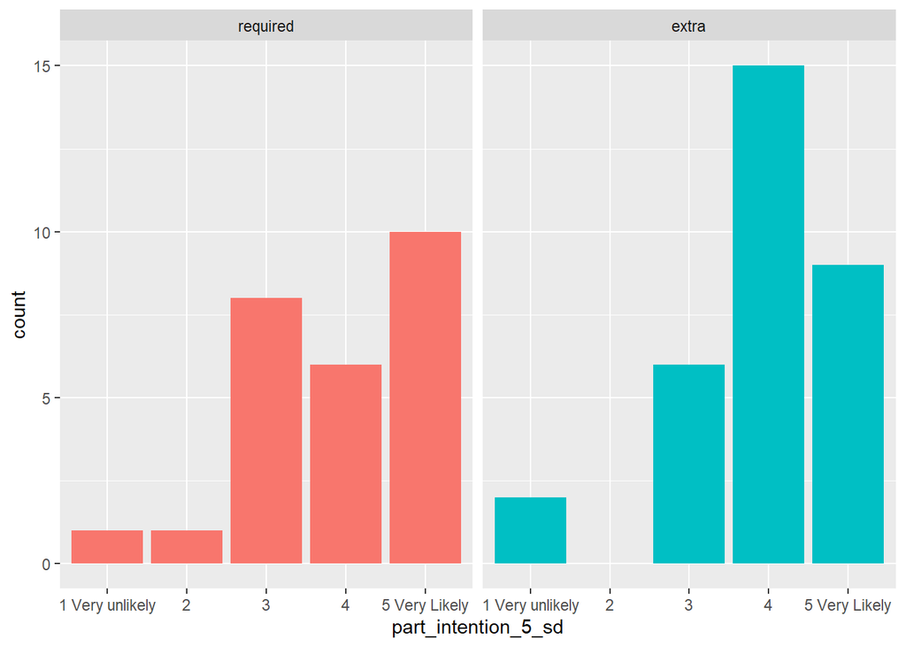

```r
# bar chart
df %>%
  filter(incent_type != 3) %>%
  filter(!is.na(part_intention_5_sd)) %>%
  mutate(part_intention_5_sd = haven::as_factor(part_intention_5_sd),
         incent_type = haven::as_factor(incent_type)) %>%
  ggplot(aes(part_intention_5_sd, fill = incent_type)) +
  geom_bar() +
  facet_wrap(~ incent_type)+
  theme(legend.position = "none")
```

```r
# means and sd's
df %>%
  select(incent_type, part_intention_5_sd) %>%
  filter(incent_type != 3) %>%
  filter(!is.na(part_intention_5_sd)) %>%
  mutate(incent_type = haven::as_factor(incent_type)) %>%
  group_by(incent_type) %>%
  summarize(count = n(),
            mean = mean(part_intention_5_sd),
            sd = sd(part_intention_5_sd))
```

```
## # A tibble: 2 × 4
##   incent_type count  mean    sd
##   <fct>       <int> <dbl> <dbl>
## 1 required       26  3.88  1.11
## 2 extra          32  3.91  1.03
```

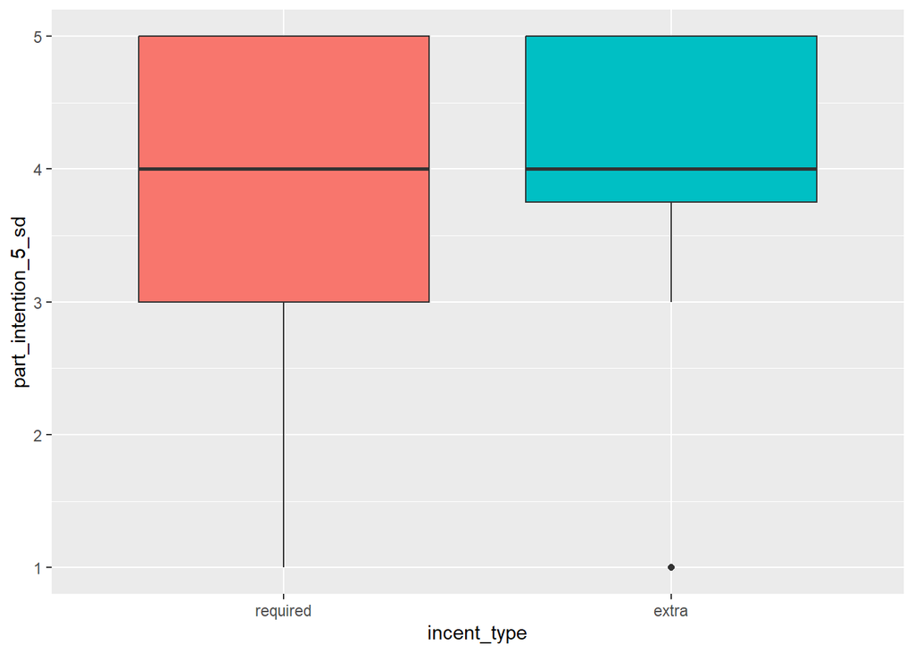

```r
#boxplot
df %>%
  select(incent_type, part_intention_5_sd) %>%
  filter(incent_type != 3) %>%
  filter(!is.na(part_intention_5_sd)) %>%
  mutate(incent_type = haven::as_factor(incent_type)) %>%
  ggplot(aes(incent_type, part_intention_5_sd, fill = incent_type)) +
  geom_boxplot() +
  theme(legend.position = "none")
```

Conclusion: Based on the three operations above, there doesn’t seem to be much differences in participation intention measured with part_intention_5_sd between the two incentive types.

- int_rp_recomend

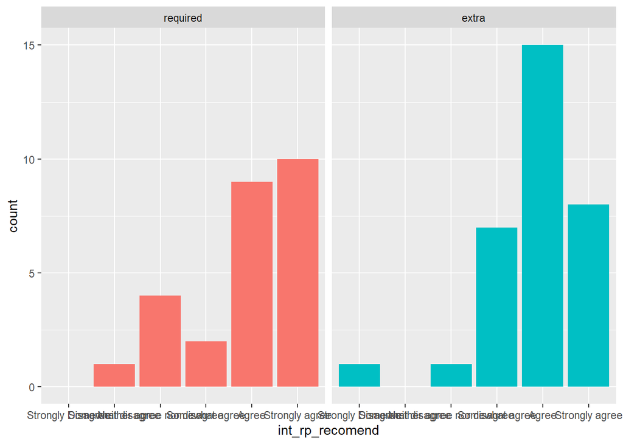

```r
# bar chart
df %>%
  filter(incent_type != 3) %>%
  filter(!is.na(int_rp_recomend)) %>%
  mutate(int_rp_recomend = haven::as_factor(int_rp_recomend),
         incent_type = haven::as_factor(incent_type)) %>%
  ggplot(aes(int_rp_recomend, fill = incent_type)) +
  geom_bar() +
  facet_wrap(~ incent_type)+
  theme(legend.position = "none")
```

```r
# means and sd's
df %>%
  select(incent_type, int_rp_recomend) %>%
  filter(incent_type != 3) %>%
  filter(!is.na(int_rp_recomend)) %>%
  mutate(incent_type = haven::as_factor(incent_type)) %>%
  group_by(incent_type) %>%
  summarize(count = n(),
            mean = mean(int_rp_recomend),
            sd = sd(int_rp_recomend))
```

```
## # A tibble: 2 × 4
##   incent_type count  mean    sd
##   <fct>       <int> <dbl> <dbl>
## 1 required       26  5.88  1.21
## 2 extra          32  5.81  1.18
```

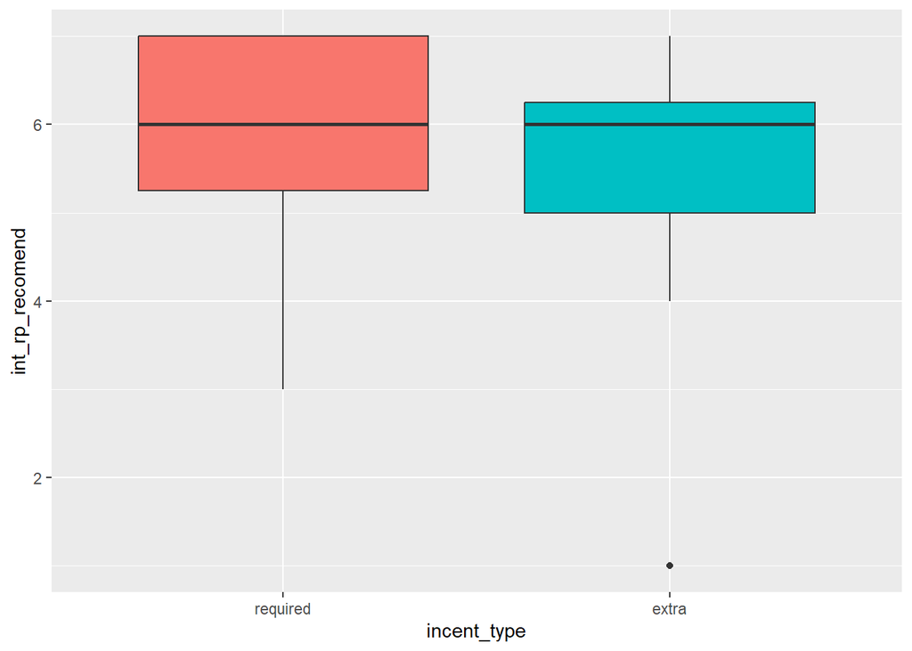

```r
#boxplot
df %>%
  select(incent_type, int_rp_recomend) %>%
  filter(incent_type != 3) %>%
  filter(!is.na(int_rp_recomend)) %>%
  mutate(incent_type = haven::as_factor(incent_type)) %>%
  ggplot(aes(incent_type, int_rp_recomend, fill = incent_type)) +
  geom_boxplot() +
  theme(legend.position = "none")
```

#### 6.1.1.6 comparision of means for all three incentive types

```r
# means and sd's
df %>%
  select(incent_type, part_intention_lt) %>%
 # filter(incent_type != 3) %>%
  filter(!is.na(part_intention_lt)) %>%
  mutate(incent_type = haven::as_factor(incent_type)) %>%
  group_by(incent_type) %>%
  summarize(count = n(),
            mean = mean(part_intention_lt),
            sd = sd(part_intention_lt))
```

```
## # A tibble: 3 × 4
##   incent_type count  mean    sd
##   <fct>       <int> <dbl> <dbl>
## 1 required       26  5.85  1.22
## 2 extra          32  5.78  1.01
## 3 both           34  5.59  1.74
```

```r
df %>%
  select(incent_type, part_intention_5_sd) %>%
 # filter(incent_type != 3) %>%
  filter(!is.na(part_intention_5_sd)) %>%
  mutate(incent_type = haven::as_factor(incent_type)) %>%
  group_by(incent_type) %>%
  summarize(count = n(),
            mean = mean(part_intention_5_sd),
            sd = sd(part_intention_5_sd))
```

```
## # A tibble: 3 × 4
##   incent_type count  mean    sd
##   <fct>       <int> <dbl> <dbl>
## 1 required       26  3.88  1.11
## 2 extra          32  3.91  1.03
## 3 both           35  3.86  1.29
```

```r
# means and sd's
df %>%
  select(incent_type, int_rp_recomend) %>%
 # filter(incent_type != 3) %>%
  filter(!is.na(int_rp_recomend)) %>%
  mutate(incent_type = haven::as_factor(incent_type)) %>%
  group_by(incent_type) %>%
  summarize(count = n(),
            mean = mean(int_rp_recomend),
            sd = sd(int_rp_recomend))
```

```
## # A tibble: 3 × 4
##   incent_type count  mean    sd
##   <fct>       <int> <dbl> <dbl>
## 1 required       26  5.88  1.21
## 2 extra          32  5.81  1.18
## 3 both           35  5.51  1.70
```

- Conclusion: Again, research participation intention measured by int_rp_recomend doesnt’ seem to be much different between the two incentive type groups.
- Based on the relationship between the incentive types and the three dependent variables explored above, we can tentatively conclude that incentive type doesn’t matter in students’ intention to participation in the future.

#### 6.1.1.7 participation intentions by credit earned

- credit_earned
- part_intention_lt

```r
df %>% count(credit_earned)
```

```
## # A tibble: 7 × 2
##   credit_earned                    n
##   <dbl+lbl>                    <int>
## 1 1 [0 sona credits]               2
## 2 2 [0.5 sona credits]             8
## 3 3 [1 sona credit]               20
## 4 4 [1.5 sona credits]            57
## 5 5 [2 sona credits]               4
## 6 6 [2.5 sona credits]             1
## 7 8 [3.5 sona credits or more]     1
```

```r
df %>% count(part_intention_lt)
```

```
## # A tibble: 8 × 2
##   part_intention_lt                   n
##   <dbl+lbl>                       <int>
## 1  1 [Strongly Disagree]              2
## 2  2 [Disagree]                       1
## 3  3 [Somewhat disagree]              2
## 4  4 [Neither agree nor disagree]    11
## 5  5 [Agree]                         16
## 6  6 [Somewhat agree]                27
## 7  7 [Strngly Agree]                 33
## 8 NA                                  1
```

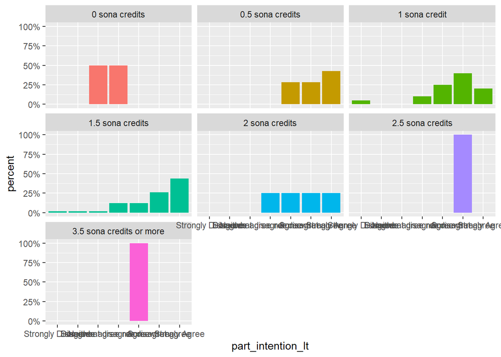

```r
# barplot with percentages
df %>%
  filter(!is.na(part_intention_lt)) %>%
  mutate(credit_earned = haven::as_factor(credit_earned),
         part_intention_lt = haven::as_factor(part_intention_lt)) %>%
  group_by(credit_earned) %>%
  count(part_intention_lt) %>%
  mutate(percent = n/sum(n)) %>%
  ggplot(aes(part_intention_lt, percent, fill = credit_earned)) +
  geom_col() +
  scale_y_continuous(labels = scales::percent_format()) +
  facet_wrap(~ credit_earned) +
  theme(legend.position = "none")
```

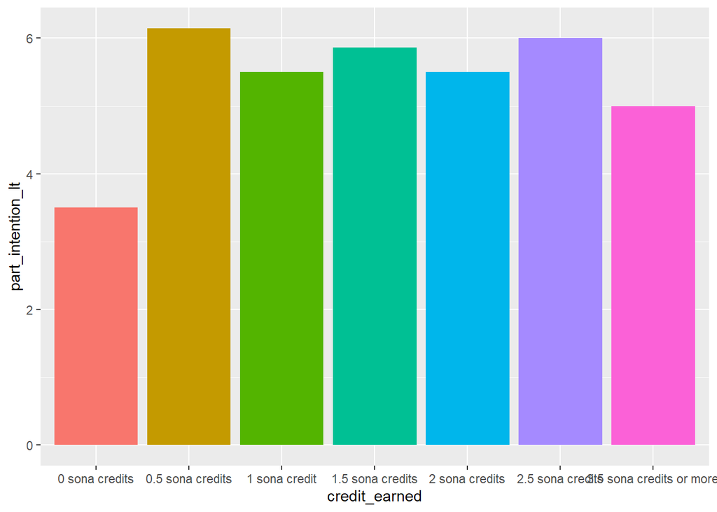

```r
# barplot
p <- df %>%
  filter(!is.na(part_intention_lt)) %>%
  mutate(credit_earned = haven::as_factor(credit_earned)) %>%
  ggplot(aes(credit_earned, part_intention_lt, fill = credit_earned))

p +
  geom_bar(stat = "summary", fun = "mean") +
  theme(legend.position = "none")
```

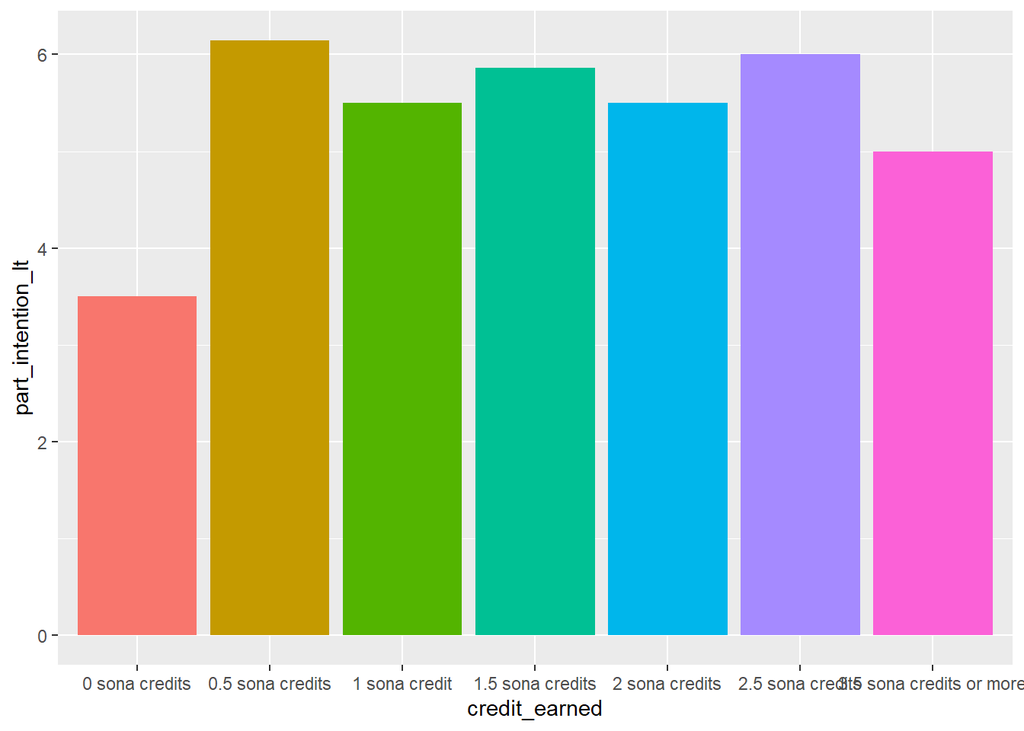

```r
# stat_summary()
p +
  stat_summary(fun = "mean", geom = "bar") +
  theme(legend.position = "none")
```

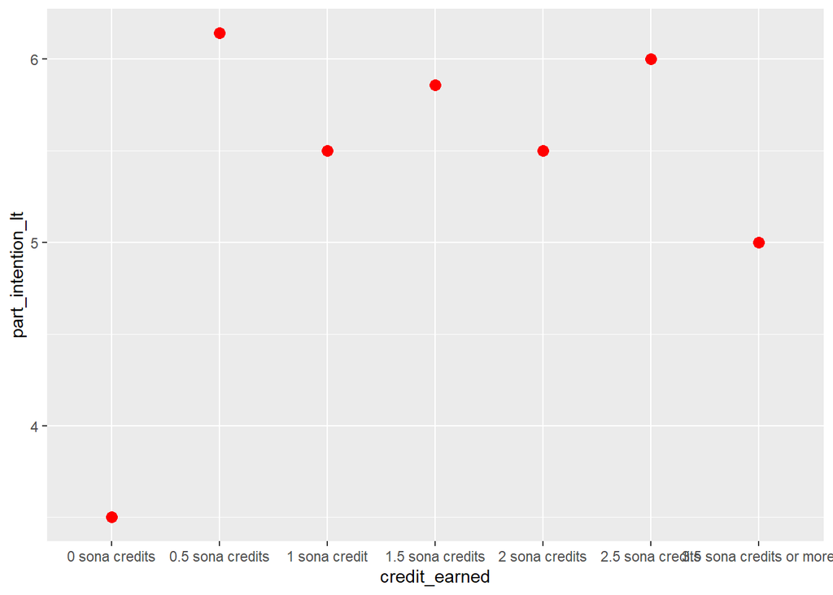

```r
p +
  stat_summary(fun = "mean", size = 3, color = "red", geom = "point") +
  #stat_summary(fun = "median", geom = "line") +
  theme(legend.position = "none")
```

* conclusion * Participation intentions tend to be lower at either the top or the bottom of the sona credit earned. * When they earned medium range of sona credits, their intentions about the same at higher end.

#### 6.1.1.8 Applying stat_summary

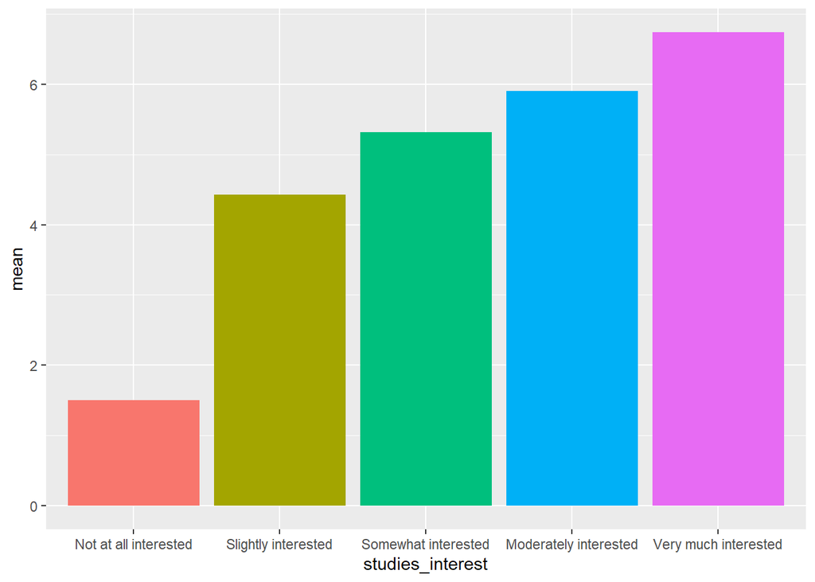

```r
# Using average participation intentions
# Using geom_col with mean value
df %>%
  filter(!is.na(part_intention_lt)) %>%
  mutate(studies_interest = haven::as_factor(studies_interest)) %>%
  group_by(studies_interest) %>%
  summarize(mean = mean(part_intention_lt)) %>%
  ggplot(aes(studies_interest, mean, fill = studies_interest)) +
  geom_col() +
  theme(legend.position = "none")
```

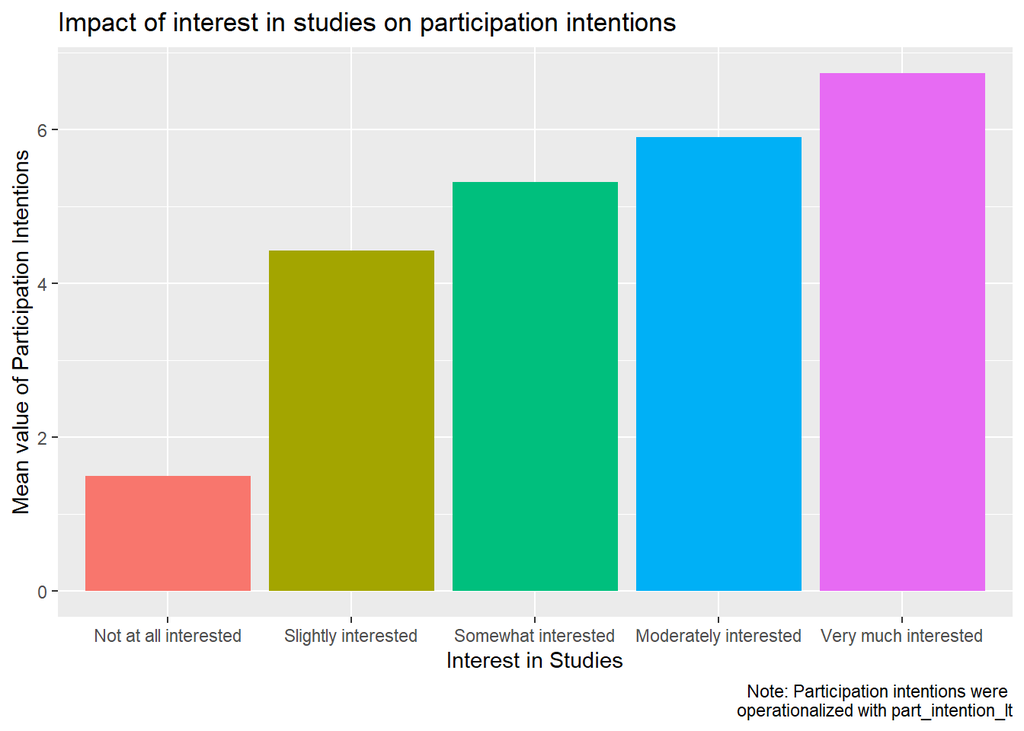

```r
# stat_summary
df %>%
  filter(!is.na(part_intention_lt)) %>%
  mutate(studies_interest = haven::as_factor(studies_interest)) %>%
  ggplot(aes(studies_interest, part_intention_lt, fill = studies_interest)) +
  stat_summary(fun = "mean", geom = "bar") +
  theme(legend.position = "none") +
  labs(x = "Interest in Studies",
       y = "Mean value of Participation Intentions",
       title = "Impact of interest in studies on participation intentions",
       caption = "Note: Participation intentions were \noperationalized with part_intention_lt")
```

### 6.1.2 Statistical Inference

#### 6.1.2.1 Correlations

#### 6.1.2.2 Regression

- used when dv is continuous while iv is either coninuous or categorical
- **Regressing part_intention_lt on iv’s**
- **Regressing part_intention_5_sd on iv’s**
- **Regressing int_rp_recomend on iv’s**

#### 6.1.2.3 One-way ANOVA

- Impact of incentive type on participation Intentions
- incent_type: 3 groups
- incent_type: 2 groups

#### 6.1.2.4 Independent samples T-test

#### 6.1.2.5 Logistic regression

- used when dv is categorical while iv is either continuous or categorical
- odds
- odds ratio
- log(odds)

## 6.2 RQ 2: How would participants’ perception of value in participation explain their attitudes toward participation in the studies? **Ally**

## 6.3 RQ 3: Would academic characteristics (e.g., overall GPA, class grade, college/majors, credit_earned) of participants influence their perception of value of participation? **Ethan**

## 6.4 RQ 4: How do individual characteristics (e.g., studies_sincerity, studies_interest) affect the value of participation? **Maddie**

## 6.5 RQ 5: Would demographic characteristics of the participants influence their attitudes towards participation? **Alyson**

## 6.6 RQ 6: Do students with higher GPAs show a greater inclination to participate in research studies compared to those with lower GPAs? **George**

# 7 Appendix

```r
df <- df |>
  rename(aff_college = q2_5,
         aff_major = q2_6)

df |> count(aff_college)
df |> count(aff_major, sort = TRUE)
```

```r
#create data frame
t1 <- data.frame(team=c('A', 'A', 'A', 'A', 'B', 'B', 'B', 'B'),
                 position=c('G', 'G', 'F', 'C', 'G', 'F', 'F', 'C'),
                 points=c(7, 7, 8, 11, 13, 15, 19, 13))

#view data frame
t1

#produce crosstab
t1 %>%
  group_by(team, position) %>%
  tally() %>%
  spread(team, n)

t1 %>%
  group_by(team, position) %>%
  tally() %>%
  pivot_wider(names_from = team, values_from = n)
```

## 7.1 mtcars data

```r
ggplot(mtcars, aes(wt, mpg)) +
  geom_point()

mtcars %>%
  lm(mpg ~ wt, data = .) %>%
  summary() %>%
  tidy()

mtcars %>%
  lm(mpg ~ wt + vs, data = .) %>%
  summary() %>%
  tidy()

## generate the dataset
set.seed(34)
soda_ounces <- rnorm(100, mean = 12, sd = 0.04)
head(soda_ounces)

## check for normality
ggplot(as.data.frame(soda_ounces))+
  geom_histogram(aes(soda_ounces), bins = 10)

## carry out One group t-test
t.test(soda_ounces, mu = 12)

# from linear regression
regression_output <-  lm(soda_ounces ~ 1)
summary(regression_output)

# calculate confidence interval
confint(regression_output)
```